# LDA Topic Extraction and Analysis

Author

Doron Feingold

Published

September 8, 2025

## Overview

LDA (Latent Dirichlet Allocation) is a probabilistic topic modeling technique that discovers hidden thematic structures in large collections of text documents. It assumes each document is a mixture of topics, and each topic is characterized by a distribution of words, allowing it to automatically identify and extract meaningful topics from unstructured text data. The model requires us to select the number of topics beforehand. Since it is unknown to us which number of topics is right, we train several LDA models with different numbers of topics (`k`). We then evaluate, compare and rank all the models’, topic quality and temporal balance. Finally we choose which number of topics is best overall.

## Setup

We load packages, most notably we load `topicmodels` for training the LDA models. we also load our `project_stopwords` and `intrusion_regex` (boilerplate), we established in the previous step.

```r
# Seed
set.seed(1867)

# Load all necessary libraries
library(dplyr)
library(tidytext)
library(tidyr)
library(stringr)
library(ggplot2)
library(topicmodels)
library(purrr)
library(patchwork)
library(tictoc)
library(Matrix)
library(cowplot)

# Load project-specific functions and data
source("R/functions.R")
clean_corpus <- readr::read_csv(
  "output/segmentation/llm_clean_segmented_corpus.csv"
)
intrusion_regex <- readRDS("output/boilerplate/intrusion_regex.rds")
project_stopwords <- get_project_stopwords()

k_values <- c(4, 6, 8, 10, 12)
```

## Pre-Processing

We prepare the text and create a single Document-Term Matrix (DTM) using `tidytext`.

```r
# Prepare tidy word list
lemmatized_policy_words <- clean_corpus %>%
  mutate(
    policy_content = str_remove_all(
      policy_content,
      regex(intrusion_regex, ignore_case = TRUE)
    )
  ) %>%
  unnest_tokens(word, policy_content) %>%
  anti_join(project_stopwords, by = "word") %>%
  mutate(lemma = textstem::lemmatize_words(word))

# Create the DTM for the topicmodels package
dtm_tm <- lemmatized_policy_words %>%
  count(filename, lemma, sort = TRUE) %>%
  cast_dtm(filename, lemma, n)
```

## Iterative LDA Topic Modeling

We now train a separate LDA model for each `k` value `k_values <- c(4, 6, 8, 10, 12)`.

```r
tic("Total training time for all models")
lda_models <- k_values %>%
  purrr::map(function(k) {
    LDA(dtm_tm, k = k, control = list(seed = 1867))
  })
toc()

saveRDS(lda_models, "output/models/lda_models.rds")
```

## Model Results and Analysis

To evaluate the results we review the following:

- **Topic Distribution by Era**: Are the topics evenly distributed across the eras?
- **Topic Prominence Over Time**: Do the topics show clear prominence trends?
- **Topic Quality**: Dominance (how often a topic is the primary theme of a speech) vs. Exclusivity (uniqueness).

### **Topic Distribution by Era**

We can see how many topics peaked in each era:

- **Pre-War** 1867 - 1940
- **Mid-Century** 1940 - 1980
- **Modern Era** 1980 - 2025

we want to see even distribution more or less so that topics are not concentrated in one time period.

#### **Era Distribution Grid**

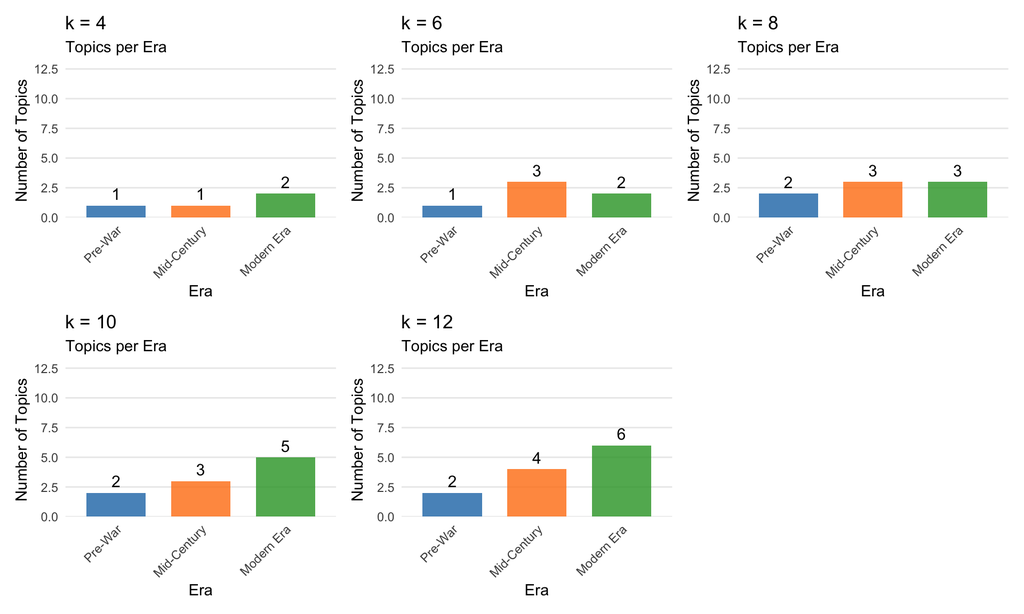

#### **Proportional Distribution**

| k_value | Pre-War % | Mid-Century % | Modern Era % |
| --- | --- | --- | --- |
| 4 | 25.0 | 25.0 | 50.0 |
| 6 | 16.7 | 50.0 | 33.3 |
| 8 | 25.0 | 37.5 | 37.5 |
| 10 | 20.0 | 30.0 | 50.0 |
| 12 | 16.7 | 33.3 | 50.0 |

#### **Era Distribution Evenness Analysis**

Lower `std_dev`, `range_spread`, and `coeff_var` = more even distribution

| k_value | Pre-War | Mid-Century | Modern Era | std_dev | range_spread | coeff_var | evenness_rank |
| --- | --- | --- | --- | --- | --- | --- | --- |
| 8 | 2 | 3 | 3 | 0.072 | 0.125 | 0.217 | 1.0 |
| 4 | 1 | 1 | 2 | 0.144 | 0.250 | 0.433 | 2.0 |
| 10 | 2 | 3 | 5 | 0.153 | 0.300 | 0.458 | 3.0 |
| 6 | 1 | 3 | 2 | 0.167 | 0.333 | 0.500 | 4.5 |
| 12 | 2 | 4 | 6 | 0.167 | 0.333 | 0.500 | 4.5 |

Most even distribution: k = **8**

### **Topic Prominence Over Time**

This plot compares the topic prominence line charts for each `k` value. A good model should show distinct and interpretable trend lines.

#### **Time Series Plot**

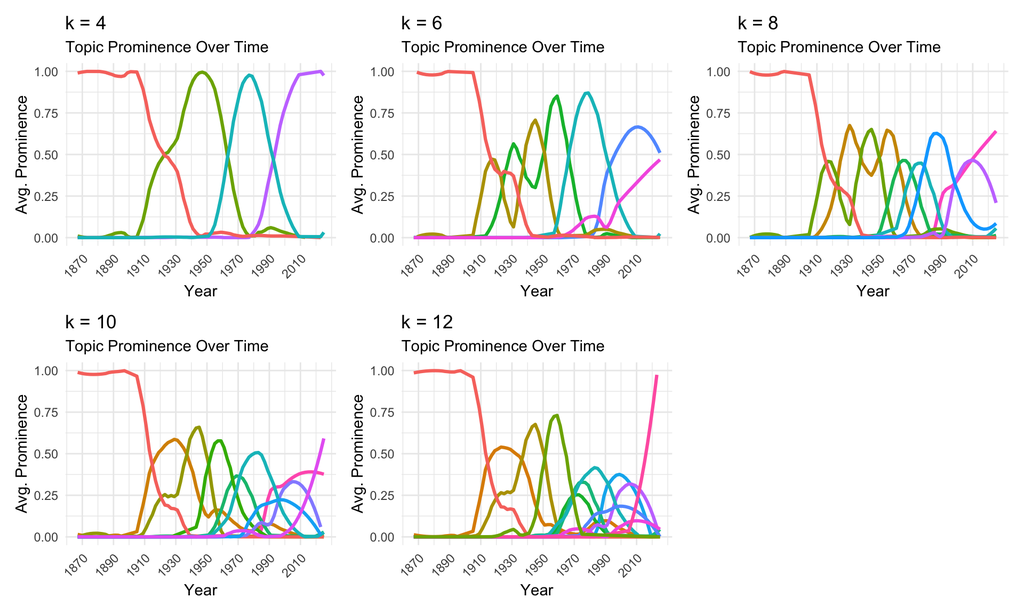

#### **Sample of yearly prominence data**

| year | topic | avg_gamma | k_value |
| --- | --- | --- | --- |
| 1867 | 1 | 0.0002554 | 4 |
| 1867 | 2 | 0.0002554 | 4 |
| 1867 | 3 | 0.9992339 | 4 |
| 1867 | 4 | 0.0002554 | 4 |
| 1869 | 1 | 0.0003494 | 4 |
| 1869 | 2 | 0.0003494 | 4 |

#### **Variance-based Analysis**

- Higher variance = more dynamic topics (some very prominent, some barely there)
- Lower variance = more balanced prominence across topics

| k_value | avg_variance | max_variance | min_variance | high_variance_topics |
| --- | --- | --- | --- | --- |
| 12 | 0.0548 | 0.2074 | 0.0123 | 12 |
| 10 | 0.0621 | 0.2059 | 0.0200 | 10 |
| 8 | 0.0778 | 0.2070 | 0.0401 | 8 |
| 6 | 0.0981 | 0.2050 | 0.0390 | 6 |
| 4 | 0.1400 | 0.2007 | 0.1037 | 4 |

Variance Analysis (lower `avg_variance` = more stable topics)

#### **“Dead Topics” Analysis**

Count topics that never achieve meaningful prominence

| k_value | total_topics | dead_topics | weak_topics | moderate_topics | strong_topics | dead_topic_pct | weak_topic_pct |
| --- | --- | --- | --- | --- | --- | --- | --- |
| 4 | 4 | 0 | 0 | 0 | 4 | 0 | 0 |
| 6 | 6 | 0 | 0 | 0 | 6 | 0 | 0 |
| 8 | 8 | 0 | 0 | 0 | 8 | 0 | 0 |
| 10 | 10 | 0 | 0 | 0 | 10 | 0 | 0 |
| 12 | 12 | 0 | 0 | 0 | 12 | 0 | 0 |

There are no “dead topics”.

#### **Prominence Range Analysis**

Look at the spread between most and least prominent topics each year.

| k_value | avg_range | avg_dominant_strength | avg_weakest_strength | max_range |
| --- | --- | --- | --- | --- |
| 4 | 0.8964 | 0.8965 | 1e-04 | 0.9999 |
| 12 | 0.8737 | 0.8737 | 0e+00 | 0.9999 |
| 8 | 0.8709 | 0.8710 | 1e-04 | 0.9999 |
| 6 | 0.8700 | 0.8701 | 1e-04 | 0.9999 |
| 10 | 0.8512 | 0.8513 | 0e+00 | 0.9999 |

Range Analysis (higher `avg_range` might = better topic separation)

#### **Combined Ranking**

| k_value | variance_rank | dead_rank | range_rank | combined_score | overall_rank |
| --- | --- | --- | --- | --- | --- |
| 12 | 1 | 3 | 2 | 6 | 1.0 |
| 4 | 5 | 3 | 1 | 9 | 2.5 |
| 8 | 3 | 3 | 3 | 9 | 2.5 |
| 10 | 2 | 3 | 5 | 10 | 4.0 |
| 6 | 4 | 3 | 4 | 11 | 5.0 |

**Combined Ranking** (lower overall rank = better model): * Variance rank: 1 = most stable topics  
* Dead rank: 1 = fewest useless topics  
* Range rank: 1 = best topic separation

### Topic Quality: Dominance vs. Exclusivity

This plot compares topic dominance (how often a topic is the primary theme of a speech) with exclusivity. This helps identify which topics are both important and unique.

#### **Dominance Plot**

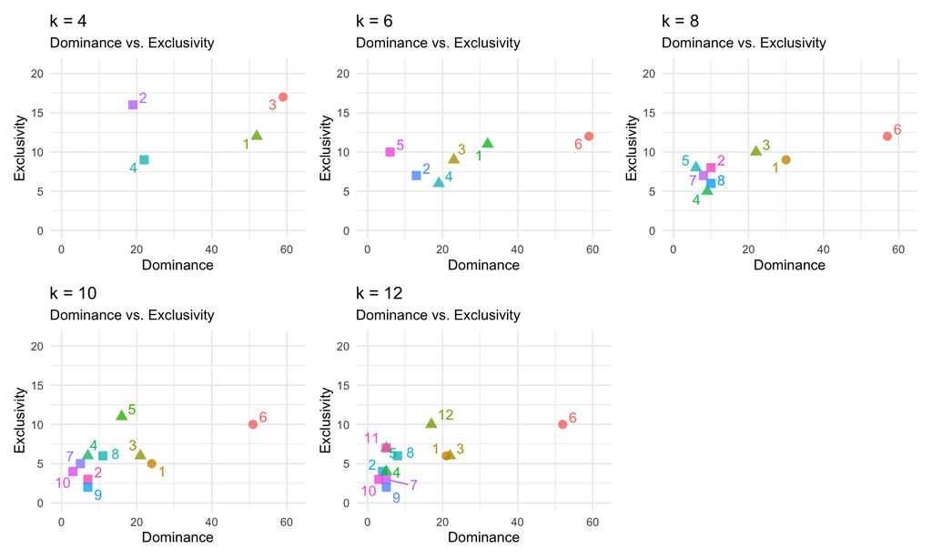

● Pre-War (pre-1940) ▲ Mid-Century (1940-1980) ■ Modern Era (1980+)

#### **Sample of topic metrics data:**

| k_value | topic | exclusivity | dominance_count | era |
| --- | --- | --- | --- | --- |
| 4 | 1 | 12 | 52 | Mid-Century |
| 4 | 2 | 16 | 19 | Modern Era |
| 4 | 3 | 17 | 59 | Pre-War |
| 4 | 4 | 9 | 22 | Modern Era |
| 6 | 1 | 11 | 32 | Mid-Century |
| 6 | 2 | 7 | 13 | Modern Era |

#### **Dominance + Exclusivity Quality Score**

Model Quality Summary (higher avg_quality_score = better):

| k_value | avg_quality_score | avg_weighted_score | high_quality_topics | balanced_topics | low_quality_topics | quality_std | avg_exclusivity | avg_dominance |
| --- | --- | --- | --- | --- | --- | --- | --- | --- |
| 4 | 0.696 | 0.710 | 2 | 1 | 0 | 0.253 | 13.5 | 38.0 |
| 6 | 0.438 | 0.446 | 1 | 1 | 3 | 0.224 | 9.2 | 25.3 |
| 8 | 0.347 | 0.359 | 1 | 0 | 5 | 0.222 | 8.1 | 19.0 |
| 10 | 0.236 | 0.239 | 0 | 1 | 8 | 0.202 | 5.8 | 15.2 |
| 12 | 0.209 | 0.216 | 1 | 0 | 9 | 0.196 | 5.7 | 12.7 |

#### **Principal Component Analysis on Dominance + Exclusivity**

```
Importance of components:
                          PC1    PC2
Standard deviation     1.3076 0.5387
Proportion of Variance 0.8549 0.1451
Cumulative Proportion  0.8549 1.0000
```

| k_value | avg_pc1 | avg_pc2 | pc1_std |
| --- | --- | --- | --- |
| 12 | 0.629 | 0.108 | 1.014 |
| 10 | 0.498 | 0.186 | 1.047 |
| 8 | -0.126 | -0.126 | 1.120 |
| 6 | -0.596 | -0.075 | 1.126 |
| 4 | -1.989 | -0.425 | 1.298 |

Variable Contributions to PC1:

```
    exclusivity dominance_count
         -0.707          -0.707
```

Correlation between Exclusivity and Dominance: **0.7098022**

#### **Topic Efficiency Analysis**

Topic Efficiency Analysis (higher efficiency_rate = more good topics per k):

| k_value | total_topics | high_quality_count | efficiency_rate | avg_exclusivity_per_topic | avg_dominance_per_topic | exclusivity_per_k | dominance_per_k |
| --- | --- | --- | --- | --- | --- | --- | --- |
| 4 | 4 | 3 | 75.0 | 13.50 | 38.00 | 13.50 | 38.00 |
| 6 | 6 | 1 | 16.7 | 9.17 | 25.33 | 9.17 | 25.33 |
| 8 | 8 | 1 | 12.5 | 8.12 | 19.00 | 8.12 | 19.00 |
| 10 | 10 | 1 | 10.0 | 5.80 | 15.20 | 5.80 | 15.20 |
| 12 | 12 | 1 | 8.3 | 5.67 | 12.67 | 5.67 | 12.67 |

#### **Final Topic Quality Ranking**

Final Ranking (lower final_rank = better dominance + exclusivity combination):

| k_value | quality_rank | pca_rank | efficiency_rank | combined_score | final_rank |
| --- | --- | --- | --- | --- | --- |
| 4 | 1 | 5 | 1 | 2.333333 | 1 |
| 6 | 2 | 4 | 2 | 2.666667 | 1 |
| 8 | 3 | 3 | 3 | 3.000000 | 1 |
| 10 | 4 | 2 | 4 | 3.333333 | 1 |
| 12 | 5 | 1 | 5 | 3.666667 | 1 |

## Conclusion

The analysis reveals a clear trade-off between topic quality and temporal balance.

**Next Step:** LLM Interpretation of Topic Models →